# Data Visualization and Analysis

By Mu Yuhong created in oct-2019

This project is divided into two major parts. In the first part, I conduct an exploratory data analysis on a dataset of your choosing. I use Python data science and data visualization libraries to explore the dataset’s variables and understand the data’s structure, oddities, patterns and relationships.

This is the second part,I take main findings from first part,exploration, and convey them to others through an explanatory analysis. To this end, I share my findings in this slide deck.

## Project Overview

The proejct aims to answer below questions:

- Who are the customers?
- When are most trips taken in terms of time of day or day of the week?
- How long does the average trip take?
- Does the above depend on if a user is a subscriber or customer?

## Datasource Overview

The data consists of information regarding 210,563 Bay Wheels's trip data captured during Aug 2019. Dataset includes

- Trip Duration (seconds)
- Start Time and Date
- End Time and Date
- Start Station ID
- Start Station Name
- Start Station Latitude
- Start Station Longitude
- End Station ID
- End Station Name
- End Station Latitude
- End Station Longitude
- Bike ID
- User Type (Subscriber or Customer – “Subscriber” = Member or “Customer” = Casual)
- Member Year of Birth
- Member Gender

The dataset can be downloaded from lfty.com official website [here](https://s3.amazonaws.com/baywheels-data/201908-baywheels-tripdata.csv.zip), with feature documentation available [here](https://www.lyft.com/bikes/bay-wheels/system-data).

## 1.User Profiling

This section aims to answer the question: Who are the customers?

The study explored three user characteristics, including

- Age
- Gender
- User type

### 1.1 Age Distribution of Users

Oberservation:

> Majority users are from 20-40 age group, who are more willingly to use bike sharing for travel.

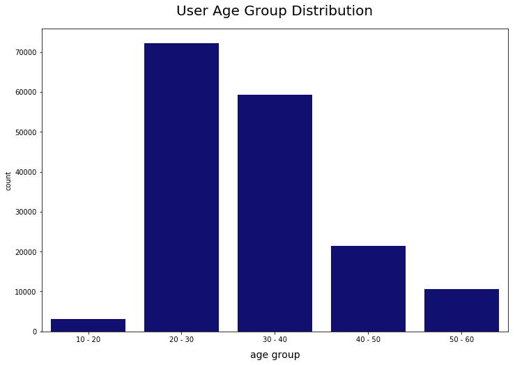

```python
plt.figure(figsize = [12, 8])
sns.countplot(x='member_age_bins', data=df.sort_values(by='member_age_bins'),color='navy')
plt.title("User Age Group Distribution", fontsize=20, y=1.03)
plt.xlabel("age group", fontsize=14, labelpad=10)
plt.xticks(rotation=360);
```

### 1.2 Count of Bike Rides by Gender

Observation:

> Number of rides made by male users tripled that of female users. The difference might caused by the population in Bay Area.

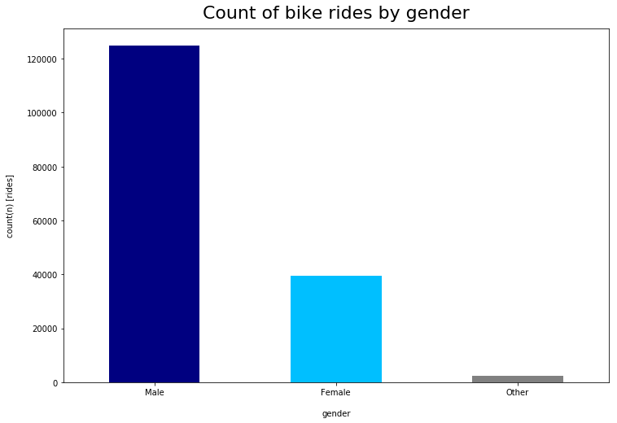

```python
df['member_gender'].value_counts().plot.bar(color=['navy','deepskyblue','gray'],figsize=(12,8), legend=False)
plt.title('Count of bike rides by gender', fontsize=22, y=1.015)
plt.xlabel('gender', labelpad=16)
plt.ylabel('count(n) [rides]', labelpad=16)
plt.xticks(rotation=360);
```

Observation:

## 2. Ride Statistics

This section aims to answer below quesitons

- When are most trips taken in terms of time of day or day of the week?
- How long does the average trip take?

Ride statistics, including

- Percentage of Bike Rides by Weekday
- Count of Rides by Each Day in Aug
- Count of Rides by Start Hour of Day

### 2.1 Percentage of Bike Rides by Weekday

Observation:

> There is a clear trend that rides made on weekdays almost double that of weekends

> The pattern might be due to different use scenarios. Users ride bikes on weekdays to commute between workplace and home, while on weekends, users ride for leisure purpose

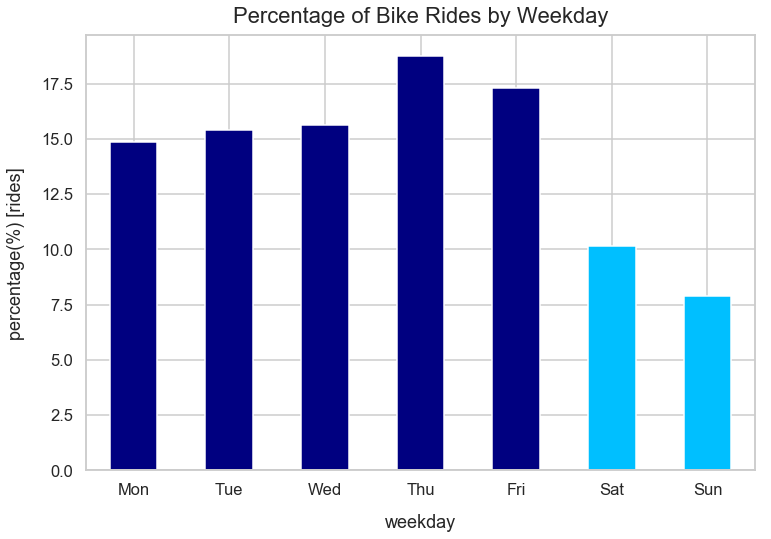

```python
#plot counts by start weekday
df_weekday = df.groupby(["start_time_weekday"]).aggregate({'bike_id':'count'})
new_color = ['navy', 'navy', 'navy', 'navy', 'navy', 'deepskyblue', 'deepskyblue']
df_weekday['perc'] = (df_weekday['bike_id']/df_weekday['bike_id'].sum())*100


df_weekday.reindex(weekday_index)['perc'].plot(kind='bar', color=new_color, figsize=(12,8), legend=False)
plt.title('Percentage of Bike Rides by Weekday', fontsize=22, y=1.015)
plt.xlabel('weekday', labelpad=16)
plt.ylabel('percentage(%) [rides]', labelpad=16)
plt.xticks(rotation=360);
```

### 2.2 Count of Rides by Each Day in Aug

Observation:

> The pattern is clear that users ride more during weekdays than weekends

> The pattern is consistent with obeservation in 2.1

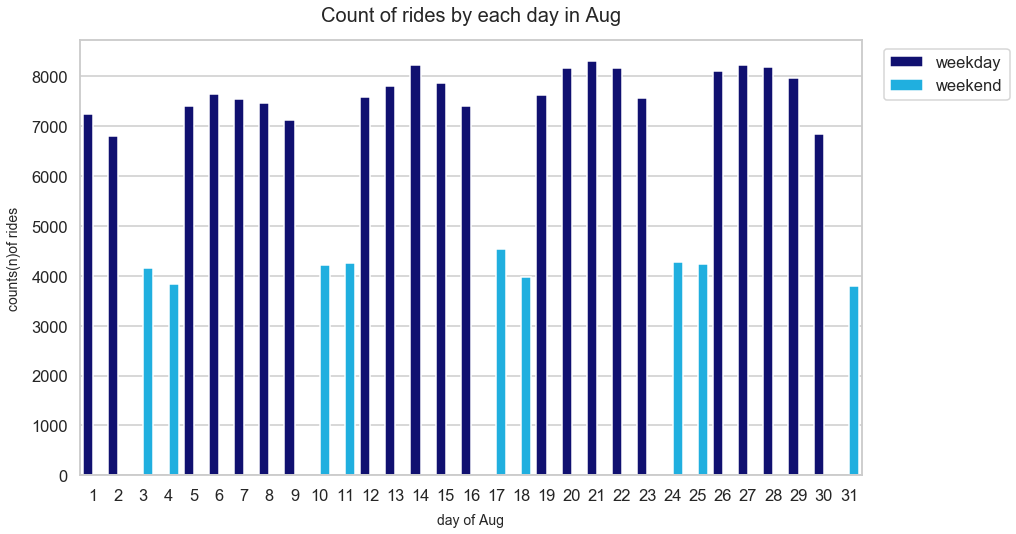

```python
#plot counts by start time on weekday and weekend
my_palette = {'weekday': 'navy', 'weekend': 'deepskyblue'}

plt.figure(figsize = [14, 8])
ax=sns.countplot(x='start_time_day',hue='weekday_or_weekend',palette=my_palette,data=df.sort_values(by=['start_time_day','weekday_or_weekend']))
plt.title("Count of rides by each day in Aug", fontsize=20, y=1.03)
plt.xlabel("day of Aug", fontsize=14, labelpad=10)
plt.ylabel("counts(n)of rides", fontsize=14, labelpad=10)
plt.xticks(rotation=360)
plt.legend(loc='upper right', bbox_to_anchor=(1.2, 1));
```

### 2.3 Count of Rides by Start Time Hour

Observations:

> Weekdays: morning peak hours start from 7am to 9am, afternoon peak hours start from 5pm to 6pm.

> Weekends: there is no obvious peak hours, users ride primarily from 9am to 8pm.

> User might ride bike on weekends for leisure purpose, while on weekdays, they ride bike to commute between work place and home

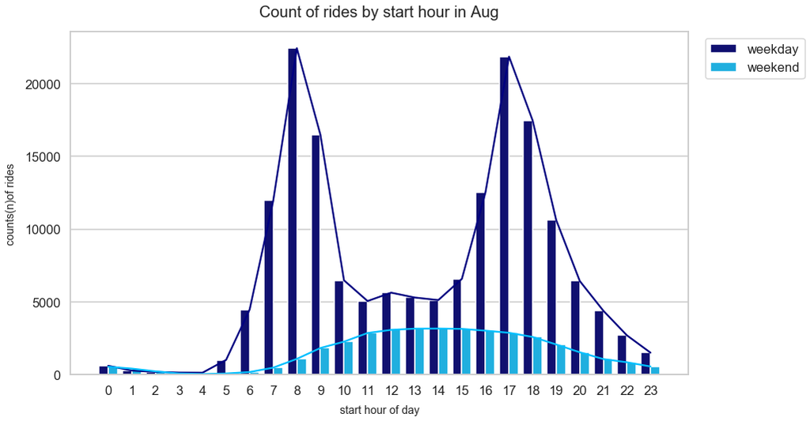

```python
#plot counts by start_time_hour on weekday and weekend
my_palette = {'weekday': 'navy', 'weekend': 'deepskyblue'}

plt.figure(figsize = [14, 8])
ax=sns.countplot(x='start_time_hour',hue='weekday_or_weekend',palette=my_palette,data=df.sort_values(by=['start_time_hour','weekday_or_weekend']))
sns.lineplot(x='start_time_hour',y='bike_id',hue='weekday_or_weekend',data=df_grp_by_start_hour,palette=my_palette,legend=False)
plt.title("Count of rides by start hour in Aug", fontsize=20, y=1.03)
plt.xlabel("start hour of day", fontsize=14, labelpad=10)
plt.ylabel("counts(n)of rides", fontsize=14, labelpad=10)
plt.xticks(rotation=360)
plt.legend(loc='upper right', bbox_to_anchor=(1.2, 1));
```

## 3. Ride Differences between Customer Group and Subscirber Group

In this section, I focus on comparing ride patterns between customer group and subscriber group

- Average Time Duration of Rides by User Type
- Average Trip Distance by User Type
- Peak Start hour by User Type

### 3.1 Average Duration of Rides by User Type

Observation:

> Average time duration for users from customer group is below 1600 seconds, which is around 27 minutes. Acoording to pricing policy, customer need to pay 2 dollar for one ride up to 30 minutes, if the ride lasts longer than 30 minutes, it's an extra 3 dollar per additional 15 minutes. A trip within 30 minutes is most beneficial for customers

> Female users ride slightly longer time duration than male users.

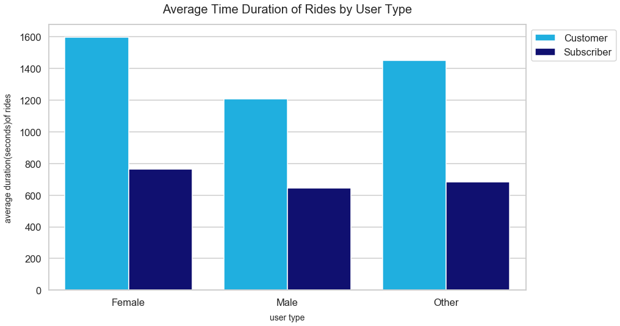

```python
my_palette = {'Subscriber': 'navy', 'Customer': 'deepskyblue'}

plt.figure(figsize = [14, 8])
ax=sns.barplot(x='member_gender',y='duration_sec',hue='user_type',palette=my_palette,data=df_duration_time_weekday.sort_values(by=['user_type','member_gender']))
#sns.lineplot(x='start_time_hour',y='bike_id',hue='weekday_or_weekend',data=df_grp_by_start_hour,palette=my_palette,legend=False)
plt.title("Average Time Duration of Rides by User Type", fontsize=20, y=1.03)
plt.xlabel("user type", fontsize=14, labelpad=10)
plt.ylabel("average duration(seconds)of rides", fontsize=14, labelpad=10)
plt.xticks(rotation=360)
plt.legend(loc='upper right', bbox_to_anchor=(1.2, 1));
```

### 3.2 Average Trip Distance by User Type

Observation:

> Users from customer group ride slightly longer distance than subscriber group.

> Although female users ride longer time duration than male users, the difference of average ride distance is insignifiant.

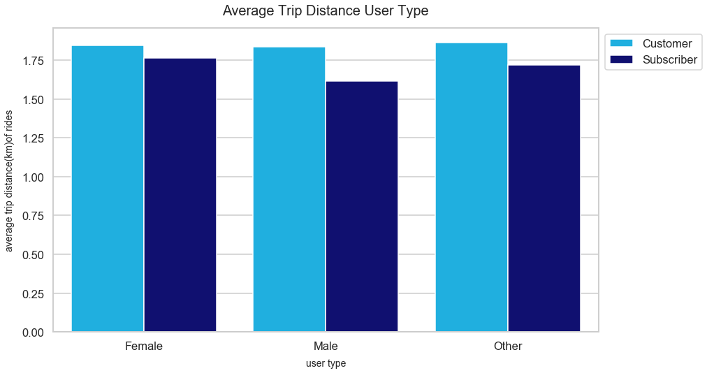

```python
my_palette = {'Subscriber': 'navy', 'Customer': 'deepskyblue'}

plt.figure(figsize = [14, 8])
ax=sns.barplot(x='member_gender',y='distance_km_estimates',hue='user_type',palette=my_palette,data=df_dist_user.sort_values(by=['user_type','member_gender']))
#sns.lineplot(x='start_time_hour',y='bike_id',hue='weekday_or_weekend',data=df_grp_by_start_hour,palette=my_palette,legend=False)
plt.title("Average Trip Distance User Type", fontsize=20, y=1.03)
plt.xlabel("user type", fontsize=14, labelpad=10)
plt.ylabel("average trip distance(km)of rides", fontsize=14, labelpad=10)
plt.xticks(rotation=360)
plt.legend(loc='upper right', bbox_to_anchor=(1.2, 1));
```

### 3.3 Peak Hours by User Type

Observation:

> Though subscriber group ride more often than customer group, both group exhibit same travel peak hours on weekdays and weekends

> Subscriber group ride much more often than customer group on weekdays, while the difference is much smaller on weekends

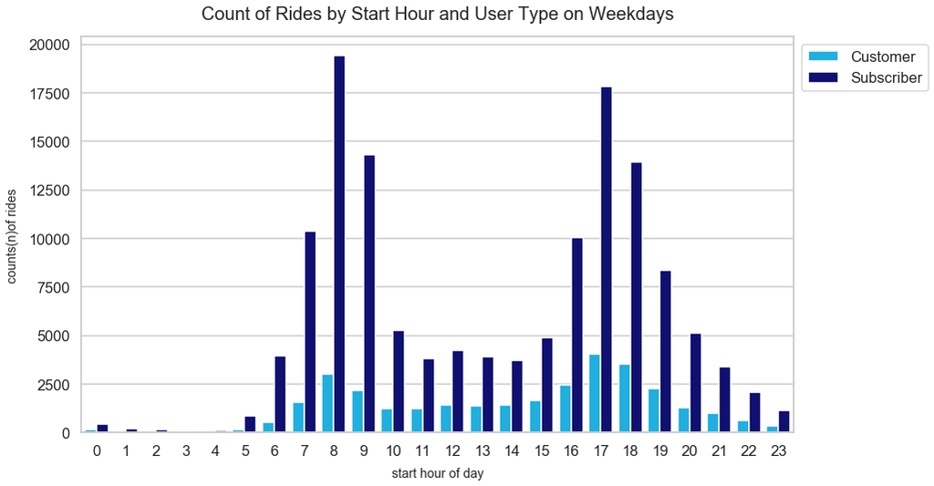

```python
#plot counts by start_time_hour and user type on weekdays
my_palette = {'Subscriber': 'navy', 'Customer': 'deepskyblue'}
plt.figure(figsize = [14, 8])
ax=sns.countplot(x='start_time_hour',hue='user_type',palette=my_palette,data=df.query('weekday_or_weekend == "weekday"').sort_values(by=['start_time_hour','user_type']))
plt.title("Count of Rides by Start Hour and User Type on Weekdays", fontsize=20, y=1.03)
plt.xlabel("start hour of day", fontsize=14, labelpad=10)
plt.ylabel("counts(n)of rides", fontsize=14, labelpad=10)
plt.xticks(rotation=360)
plt.legend(loc='upper right', bbox_to_anchor=(1.2, 1));
```

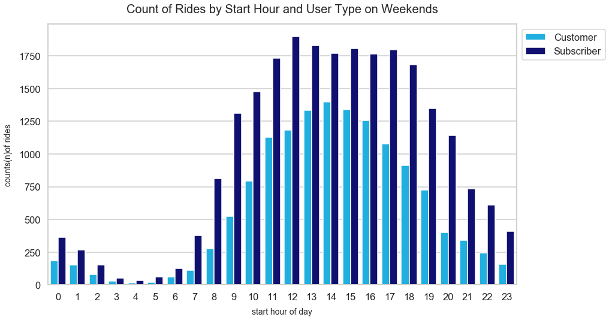

```python
my_palette2 = {'Subscriber': 'navy', 'Customer': 'deepskyblue'}
plt.figure(figsize = [14, 8])
#ax=sns.countplot(x='start_time_hour',hue='user_type',palette=my_palette,data=df.query('weekday_or_weekend == "weekday"').sort_values(by=['start_time_hour','user_type']))
ax=sns.countplot(x='start_time_hour',hue='user_type',palette=my_palette2,data=df.query('weekday_or_weekend == "weekend"').sort_values(by=['start_time_hour','user_type']))
plt.title("Count of Rides by Start Hour and User Type on Weekends", fontsize=20, y=1.03)
plt.xlabel("start hour of day", fontsize=14, labelpad=10)
plt.ylabel("counts(n)of rides", fontsize=14, labelpad=10)
plt.xticks(rotation=360)
plt.legend(loc='upper right', bbox_to_anchor=(1.2, 1));
```

## 4. Hourly Usage Differences on Weekdays between Customer Group and Subscriber Group

Observations:

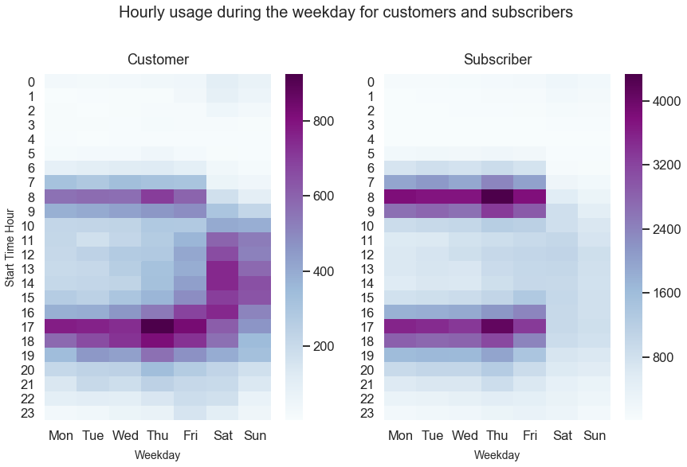

```python
# Setting the weekday order
df['start_time_weekday'] = pd.Categorical(df['start_time_weekday'],
                                                categories=['Mon','Tue','Wed','Thu','Fri','Sat', 'Sun'],
                                                ordered=True)
plt.figure(figsize=(14,8))
plt.suptitle('Hourly usage during the weekday for customers and subscribers', fontsize=20, y=1.03)

# heatmap for customers
plt.subplot(1, 2, 1)

df_customer = df.query('user_type == "Customer"').groupby(["start_time_hour", "start_time_weekday"])["bike_id"].size().reset_index()
df_customer = df_customer.pivot("start_time_hour", "start_time_weekday", "bike_id")
sns.heatmap(df_customer, cmap="BuPu",fmt='d')

plt.title("Customer", y=1.015)
plt.xlabel('Weekday',fontsize=14, labelpad=10)
plt.ylabel('Start Time Hour',fontsize=14)

# heatmap for subscribers
plt.subplot(1, 2, 2)
df_subscriber = df.query('user_type == "Subscriber"').groupby(["start_time_hour", "start_time_weekday"])["bike_id"].size().reset_index()
df_subscriber = df_subscriber.pivot("start_time_hour", "start_time_weekday", "bike_id")
sns.heatmap(df_subscriber, cmap="BuPu",fmt='d')

plt.title("Subscriber", y=1.015)
plt.xlabel('Weekday',fontsize=14, labelpad=10)
plt.ylabel('');
```

**Thoughts for Discussion：**

The behaviour difference could be further related to different [pricing policies](https://www.lyft.com/bikes/bay-wheels/pricing). The subscriber membership plan is more attractive to frequent riders, who pay fixed membership fee by monthly or annually to enjoy unlimited trips. Subscribers are more willingly to use sharing bike to commute to work.

Customers pay by each ride and ride bikes more often on weekends for leisure purpose.